# R Notebook

```r
library(dplyr)
library(readr)
library(magrittr)
```

```r
pokemon <- read_csv("Pokemon.csv", show_col_types = FALSE)
```

### The first task will be do to some data cleaning

Lets first check the data types and then go from there.

```r
str(pokemon)
```

```
spc_tbl_ [800 × 13] (S3: spec_tbl_df/tbl_df/tbl/data.frame)
 $ #         : num [1:800] 1 2 3 3 4 5 6 6 6 7 ...
 $ Name      : chr [1:800] "Bulbasaur" "Ivysaur" "Venusaur" "VenusaurMega Venusaur" ...
 $ Type 1    : chr [1:800] "Grass" "Grass" "Grass" "Grass" ...
 $ Type 2    : chr [1:800] "Poison" "Poison" "Poison" "Poison" ...
 $ Total     : num [1:800] 318 405 525 625 309 405 534 634 634 314 ...
 $ HP        : num [1:800] 45 60 80 80 39 58 78 78 78 44 ...
 $ Attack    : num [1:800] 49 62 82 100 52 64 84 130 104 48 ...
 $ Defense   : num [1:800] 49 63 83 123 43 58 78 111 78 65 ...
 $ Sp. Atk   : num [1:800] 65 80 100 122 60 80 109 130 159 50 ...
 $ Sp. Def   : num [1:800] 65 80 100 120 50 65 85 85 115 64 ...
 $ Speed     : num [1:800] 45 60 80 80 65 80 100 100 100 43 ...
 $ Generation: num [1:800] 1 1 1 1 1 1 1 1 1 1 ...
 $ Legendary : logi [1:800] FALSE FALSE FALSE FALSE FALSE FALSE ...
 - attr(*, "spec")=
  .. cols(
  ..   `#` = col_double(),
  ..   Name = col_character(),
  ..   `Type 1` = col_character(),
  ..   `Type 2` = col_character(),
  ..   Total = col_double(),
  ..   HP = col_double(),
  ..   Attack = col_double(),
  ..   Defense = col_double(),
  ..   `Sp. Atk` = col_double(),
  ..   `Sp. Def` = col_double(),
  ..   Speed = col_double(),
  ..   Generation = col_double(),
  ..   Legendary = col_logical()
  .. )
 - attr(*, "problems")=<externalptr>
```

Determine if there are any stats that are out of range.

```r
pokemon %>%
  select(-"#", -"Name", -"Type 1", -"Type 2", -"Legendary") %>%
  summarise_all(range, na.rm = TRUE)
```

| Total | HP | Attack | Defense | Sp. Atk | Sp. Def | Speed | Generation |
| --- | --- | --- | --- | --- | --- | --- | --- |
| 180 | 1 | 5 | 5 | 10 | 20 | 5 | 1 |
| 780 | 255 | 190 | 230 | 194 | 230 | 180 | 6 |

To knowledge, nothing here seems out of range.

See if there are any missing values:

```r
colSums(is.na(pokemon))
```

```
         #       Name     Type 1     Type 2      Total         HP     Attack    Defense    Sp. Atk
         0          0          0        386          0          0          0          0          0
   Sp. Def      Speed Generation  Legendary
         0          0          0          0
```

The “Type 2” has 386 missing values. However, this is normal because not every Pokemon has two types.

Check the names of the Pokemon in the “names” column.

```r
pokemon %>%
  select("Name") %>%
  filter(grepl("Mega", Name))
```

| Name |
| --- |
| VenusaurMega Venusaur |
| CharizardMega Charizard X |
| CharizardMega Charizard Y |
| BlastoiseMega Blastoise |
| BeedrillMega Beedrill |
| PidgeotMega Pidgeot |
| AlakazamMega Alakazam |
| SlowbroMega Slowbro |
| GengarMega Gengar |
| KangaskhanMega Kangaskhan |

[output cut: 39 more lines]

```r
NA
```

Consequently, this column will need the Pokemon name to be removed before the “Mega” part.

```r
pokemon$Name <- gsub(".*(Mega)", "\\1", pokemon$Name)
```

```r
pokemon %>%
  select("Name") %>%
  filter(grepl("Mega", Name))
```

| Name |
| --- |
| Mega Venusaur |
| Mega Charizard X |
| Mega Charizard Y |
| Mega Blastoise |
| Mega Beedrill |
| Mega Pidgeot |
| Mega Alakazam |
| Mega Slowbro |
| Mega Gengar |
| Mega Kangaskhan |

[output cut: 39 more lines]

This column was successfully cleaned. There is a row with the Pokemon name, “Meganium”, but there is no Mega Meganium in this dataset, so this won’t require further attention.

See if there are any types that are out of the ordinary.

```r
pokemon %>%
  select("Type 1") %>%
  unique()
```

| Type 1 |
| --- |
| Grass |
| Fire |
| Water |
| Bug |
| Normal |
| Poison |
| Electric |
| Ground |
| Fairy |
| Fighting |

[output cut: 8 more lines]

```r
pokemon %>%
  select("Type 2") %>%
  unique()
```

| Type 2 |
| --- |
| Poison |
| NA |
| Flying |
| Dragon |
| Ground |
| Fairy |
| Grass |
| Fighting |
| Psychic |
| Steel |

[output cut: 9 more lines]

Nothing here seems out of the ordinary. The only next step would be to convert the characters to factors.

```r
pokemon <- pokemon %>%
  mutate(`Type 1` = as.factor(`Type 1`),
         `Type 2` = as.factor(`Type 2`),
        # `Legendary` = as.factor(ifelse(`Legendary`, "Yes", "No"))
         )

head(pokemon)
```

| # | Name | Type 1 | Type 2 | Total | HP | Attack | Defense | Sp. Atk | Sp. Def | Speed | Generation | Legendary |
| --- | --- | --- | --- | --- | --- | --- | --- | --- | --- | --- | --- | --- |
| 1 | Bulbasaur | Grass | Poison | 318 | 45 | 49 | 49 | 65 | 65 | 45 | 1 | FALSE |
| 2 | Ivysaur | Grass | Poison | 405 | 60 | 62 | 63 | 80 | 80 | 60 | 1 | FALSE |
| 3 | Venusaur | Grass | Poison | 525 | 80 | 82 | 83 | 100 | 100 | 80 | 1 | FALSE |
| 3 | Mega Venusaur | Grass | Poison | 625 | 80 | 100 | 123 | 122 | 120 | 80 | 1 | FALSE |
| 4 | Charmander | Fire | NA | 309 | 39 | 52 | 43 | 60 | 50 | 65 | 1 | FALSE |
| 5 | Charmeleon | Fire | NA | 405 | 58 | 64 | 58 | 80 | 65 | 80 | 1 | FALSE |

Now all the data types are converted correctly, and the data is ready for analysis.

### Exploratory Data Analysis

**Main question: What two stats, if any, can predict the type of Pokemon?**

```r
library(ggplot2)
```

```r
head(pokemon)
```

| # | Name | Type 1 | Type 2 | Total | HP | Attack | Defense | Sp. Atk | Sp. Def | Speed | Generation | Legendary |
| --- | --- | --- | --- | --- | --- | --- | --- | --- | --- | --- | --- | --- |
| 1 | Bulbasaur | Grass | Poison | 318 | 45 | 49 | 49 | 65 | 65 | 45 | 1 | FALSE |
| 2 | Ivysaur | Grass | Poison | 405 | 60 | 62 | 63 | 80 | 80 | 60 | 1 | FALSE |
| 3 | Venusaur | Grass | Poison | 525 | 80 | 82 | 83 | 100 | 100 | 80 | 1 | FALSE |
| 3 | Mega Venusaur | Grass | Poison | 625 | 80 | 100 | 123 | 122 | 120 | 80 | 1 | FALSE |
| 4 | Charmander | Fire | NA | 309 | 39 | 52 | 43 | 60 | 50 | 65 | 1 | FALSE |
| 5 | Charmeleon | Fire | NA | 405 | 58 | 64 | 58 | 80 | 65 | 80 | 1 | FALSE |

Is there a certain type of Pokemon with noticeably different total stats than the others?

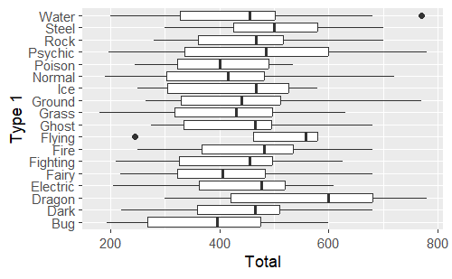

```r
ggplot(pokemon, aes(y = `Type 1`, x = Total)) +
  geom_boxplot()
```

Dragon and Flying seem to have higher stats than the other Pokemon. In the game, some types tend to have more legendary Pokemon than others. This could possibly skew the analysis. The first step will be to answer a few questions about Legendary Pokemon.

Are non-legendary Pokemon likely to have lower stats than other Pokemon, in general?

```r
legendary <- pokemon %>%
  group_by(Legendary) %>%
  summarize(meanTotal = mean(Total),
         standardDev = sd(Total),
         number = n())
legendary
```

| Legendary | meanTotal | standardDev | number |
| --- | --- | --- | --- |
| FALSE | 417.2136 | 106.76042 | 735 |
| TRUE | 637.3846 | 60.93739 | 65 |

To determine whether this is statistically significant, a t-test will be performed. First, however, the assumptions will be checked: - Is the data normally distributed - Are the samples random subsets of a larger population - Is each observation independent - Are the sample sizes large enough

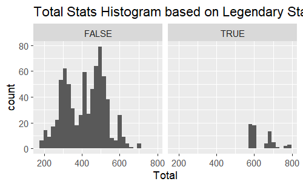

```r
ggplot(pokemon, aes(x = Total)) +
  geom_histogram() +
  facet_wrap(~Legendary) +
  ggtitle("Total Stats Histogram based on Legendary Status")
```

Legendary Pokemon do not appear to have a normally distributed stat total, so the data will need to be ranked and non-parametric test will be used.

The most appropriate test would be a Wilcoxon Mann-Whitney test since it is roughly equivalent to a t test, but uses ranked data instead.

```r
wilcox.test(
  Total ~ Legendary,
  data = pokemon,
  alternative = "less",
  correct = FALSE
)
```

```
    Wilcoxon rank sum test

data:  Total by Legendary
W = 1485.5, p-value < 2.2e-16
alternative hypothesis: true location shift is less than 0
```

This tests shows that non-legendary Pokemon have lower stats than legendary Pokemon, in general.

**So, if that is the case, should we discard legendary Pokemon from the analysis?**

One way to answer this would be to analyze the proportion of legendary Pokemon for each type.

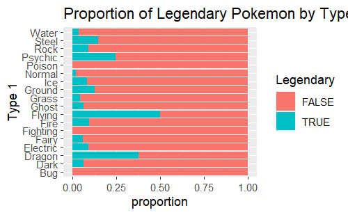

```r
ggplot(pokemon, aes(y = `Type 1`, fill = Legendary)) +
  geom_bar(position = "fill") +
  xlab("proportion") +
  ggtitle("Proportion of Legendary Pokemon by Type 1")
```

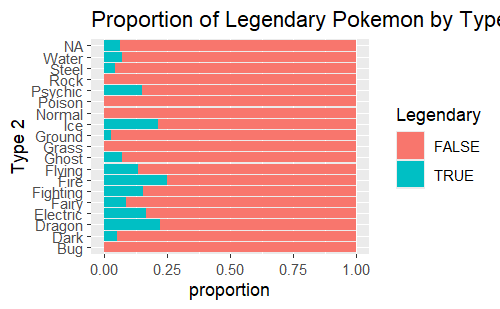

```r
ggplot(pokemon, aes(y = `Type 2`, fill = Legendary)) +
  geom_bar(position = "fill") +
  xlab("proportion") +
  ggtitle("Proportion of Legendary Pokemon by Type 2")
```

These plots show some Pokemon types have much higher proportions of legendary Pokemon. Let’s examine how the Pokemon stats are influenced by legendary status to get a more granular understanding.

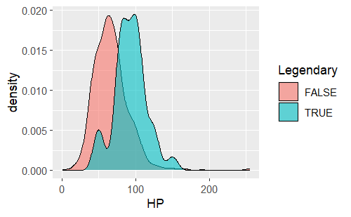

```r
ggplot(pokemon, aes(x = HP, fill = Legendary)) +
  geom_density(alpha = 0.6)
```

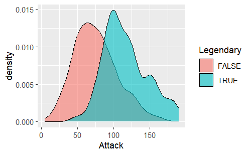

```r
ggplot(pokemon, aes(x = Attack, fill = Legendary)) +
  geom_density(alpha = 0.6)
```

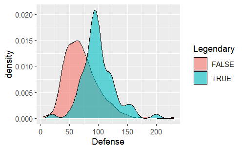

```r
ggplot(pokemon, aes(x = Defense, fill = Legendary)) +
  geom_density(alpha = 0.6)
```

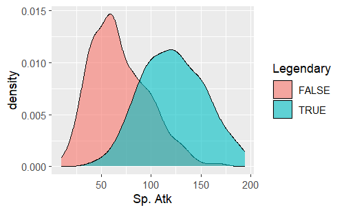

```r
ggplot(pokemon, aes(x = `Sp. Atk`, fill = Legendary)) +
  geom_density(alpha = 0.6)
```

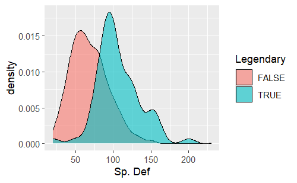

```r
ggplot(pokemon, aes(x = `Sp. Def`, fill = Legendary)) +
  geom_density(alpha = 0.6)
```

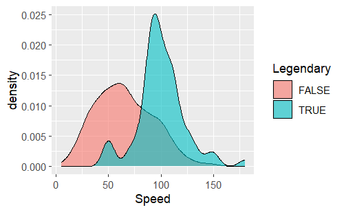

```r
ggplot(pokemon, aes(x = Speed, fill = Legendary)) +
  geom_density(alpha = 0.6)
```

These plots show that overall, each stat is skewed positively depending on legendary status. Since there are disproportionate numbers of legendary Pokemon in each type, would it be better to thus remove the legendary Pokemon from the analysis to prevent skewing? How much data could be affected?

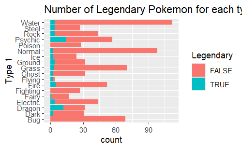

```r
ggplot(pokemon, aes(y = `Type 1`, fill = Legendary)) +
  geom_bar() +
  ggtitle("Number of Legendary Pokemon for each type")
```

```r
propLegendaryByType <- pokemon %>%
  group_by(`Type 1`) %>%
  summarize(count = n(),
            NumLegendary = sum(`Legendary`),
            propLegendary = round(NumLegendary/count, 2))

propLegendaryByType
```

| Type 1 | count | NumLegendary | propLegendary |
| --- | --- | --- | --- |
| Bug | 69 | 0 | 0.00 |
| Dark | 31 | 2 | 0.06 |
| Dragon | 32 | 12 | 0.38 |
| Electric | 44 | 4 | 0.09 |
| Fairy | 17 | 1 | 0.06 |
| Fighting | 27 | 0 | 0.00 |
| Fire | 52 | 5 | 0.10 |
| Flying | 4 | 2 | 0.50 |
| Ghost | 32 | 2 | 0.06 |
| Grass | 70 | 3 | 0.04 |

[output cut: 8 more lines]

```r
legendaryTotal <- data.frame(
  Total_Pokemon = sum(propLegendaryByType$count),
  Total_Legendary = sum(propLegendaryByType$NumLegendary)
)

legendaryTotal <- mutate(legendaryTotal, Prop_Legendary = Total_Legendary/Total_Pokemon)

legendaryTotal
```

| Total_Pokemon | Total_Legendary | Prop_Legendary |
| --- | --- | --- |
| 800 | 65 | 0.08125 |

Seeing as Legendary Pokemon only account for 8.1% of the dataset, it might be best to exclude them from the analysis to reduce bias and potential inaccuracy from machine learning models.

```r
pokemon_reg <- pokemon %>%
  filter(Legendary == FALSE)

dim(pokemon_reg)
```

```
[1] 735  13
```

The data was successfully filtered to include only regular (reg) Pokemon.

**Do any two stats stand out as potential for being most predictive of Pokemon type?**

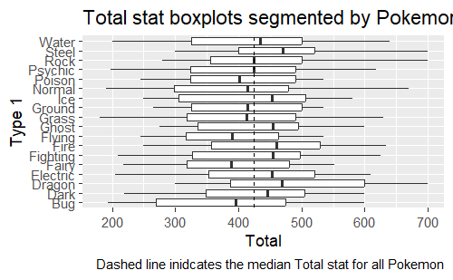

```r
ggplot(pokemon_reg, aes(y = `Type 1`, x = Total)) +
  geom_boxplot() +
  geom_vline(aes(xintercept = median(Total)), linetype = 2) +
  labs(caption = "Dashed line inidcates the median Total stat for all Pokemon") +
  ggtitle("Total stat boxplots segmented by Pokemon Type 1")
```

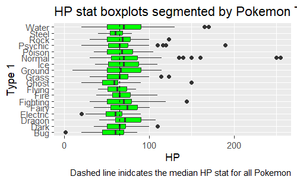

```r
ggplot(pokemon_reg, aes(y = `Type 1`, x = HP)) +
  geom_boxplot(fill = "green") +
  geom_vline(aes(xintercept = median(HP)), linetype = 2) +
  labs(caption = "Dashed line inidcates the median HP stat for all Pokemon") +
  ggtitle("HP stat boxplots segmented by Pokemon Type 1")
```

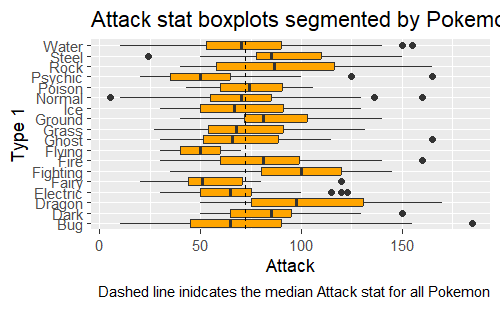

```r
ggplot(pokemon_reg, aes(y = `Type 1`, x = Attack)) +
  geom_boxplot(fill = "orange") +
  geom_vline(aes(xintercept = median(Attack)), linetype = 2) +
  labs(caption = "Dashed line inidcates the median Attack stat for all Pokemon") +
  ggtitle("Attack stat boxplots segmented by Pokemon Type 1")
```

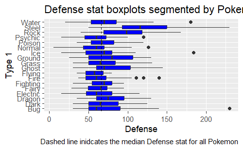

```r
ggplot(pokemon_reg, aes(y = `Type 1`, x = Defense)) +
  geom_boxplot(fill = "blue") +
  geom_vline(aes(xintercept = median(Defense)), linetype = 2) +
  labs(caption = "Dashed line inidcates the median Defense stat for all Pokemon") +
  ggtitle("Defense stat boxplots segmented by Pokemon Type 1")
```

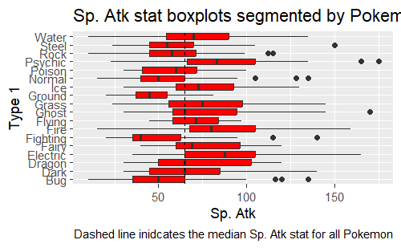

```r
ggplot(pokemon_reg, aes(y = `Type 1`, x = `Sp. Atk`)) +
  geom_boxplot(fill = "red") +
  geom_vline(aes(xintercept = median(`Sp. Atk`)), linetype = 2) +
  labs(caption = "Dashed line inidcates the median Sp. Atk stat for all Pokemon") +
  ggtitle("Sp. Atk stat boxplots segmented by Pokemon Type 1")
```

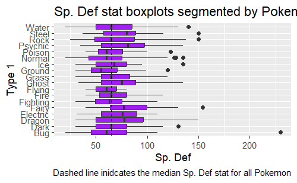

```r
ggplot(pokemon_reg, aes(y = `Type 1`, x = `Sp. Def`)) +
  geom_boxplot(fill = "purple") +
  geom_vline(aes(xintercept = median(`Sp. Def`)), linetype = 2) +
  labs(caption = "Dashed line inidcates the median Sp. Def stat for all Pokemon") +
  ggtitle("Sp. Def stat boxplots segmented by Pokemon Type 1")
```

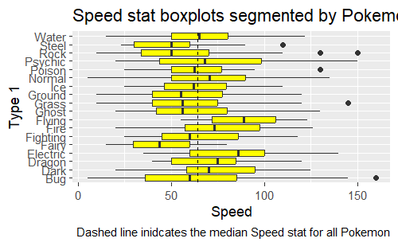

```r
ggplot(pokemon_reg, aes(y = `Type 1`, x = Speed)) +
  geom_boxplot(fill = "yellow") +
  geom_vline(aes(xintercept = median(Speed)), linetype = 2) +
  labs(caption = "Dashed line inidcates the median Speed stat for all Pokemon") +
  ggtitle("Speed stat boxplots segmented by Pokemon Type 1")
```

From initial exploration, there seems to be some separation between differing Type 1 Pokemon based on their Attack and Sp. Atk., moderate separation based on their Speed and Defense, and not much separation based on their HP and Sp. Def.

Could further separation be realized if the Attack and Sp. Attack were combined into a combined Attack, as well as a combined Defense?

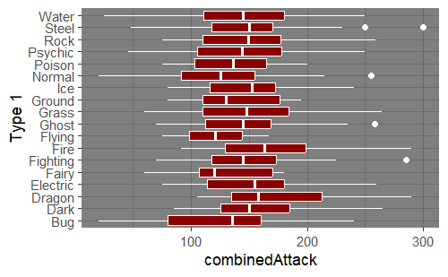

```r
combined_stats <- pokemon_reg %>%
  mutate(combinedAttack = Attack + `Sp. Atk`,
         combinedDefense = Defense + `Sp. Def`)

ggplot(combined_stats, aes(y = `Type 1`, x = combinedAttack)) +
  geom_boxplot(fill = "dark red", color = "white") +
  theme_dark()
```

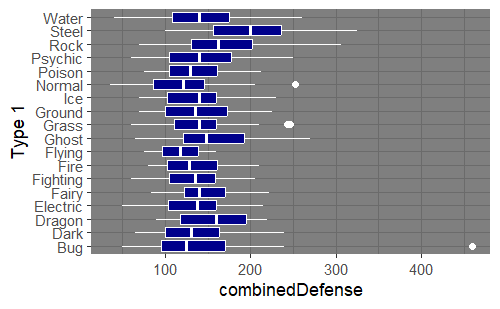

```r
ggplot(combined_stats, aes(y = `Type 1`, x = combinedDefense)) +
  geom_boxplot(fill = "dark blue", color = "white") +
  theme_dark()
```

These combined stats seems to dampen the separation.